# Cardio Good Fitness Project - Dataset Analysis & Recommendations

Objective: The objective of this project is to analyse the available dataset in 'CardioGoodFitness.csv', and as an outcome:

- Come up with a customer profile (characteristics of a customer) of the different products
- Perform univariate and multivariate analyses
- Generate a set of insights and recommendations that will help the company in targeting new customers.

##### Importing libraries to help with reading and manipulating data

```python
# Libraries to help with reading and manipulating data
import numpy as np
import pandas as pd

# Libraries to help with data visualization
import matplotlib.pyplot as plt
import seaborn as sns

# to restrict the float value to 3 decimal places
pd.set_option('display.float_format', lambda x: '%.3f' % x)
```

##### Importing the dataset

```python
#load the csv file
df = pd.read_csv('/Users/saumy/OneDrive/Documents/PG-AIML/CardioGoodFitness.csv')
```

### Data Overview

We will start with first performing basic steps to understand the nature of the data:

- Observing the first few rows of the dataset
- Understanding the shape of the dataset, and get information about the number of rows and columns
- Understanding the datatypes of the columns, and checking for missing values
- Checking the statistical summary of the data in the sheet
- Checking for duplicates in the dataset

#### Displaying the first few rows of the dataset

```python
#load the first few rows of the dataset
df.head()
```

|  | Product | Age | Gender | Education | MaritalStatus | Usage | Fitness | Income | Miles |
| --- | --- | --- | --- | --- | --- | --- | --- | --- | --- |
| 0 | TM195 | 18 | Male | 14 | Single | 3 | 4 | 29562 | 112 |
| 1 | TM195 | 19 | Male | 15 | Single | 2 | 3 | 31836 | 75 |
| 2 | TM195 | 19 | Female | 14 | Partnered | 4 | 3 | 30699 | 66 |
| 3 | TM195 | 19 | Male | 12 | Single | 3 | 3 | 32973 | 85 |
| 4 | TM195 | 20 | Male | 13 | Partnered | 4 | 2 | 35247 | 47 |

Observations:

- The dataset has been correctly loaded.
- The dataset has the following categories of information:
  - Demographic (Age, Gender, Education, Marital Status)
  - Economic (Income)
  - Health (Usage, Fitness, Miles)
  - Product (Product)

#### Understanding the shape of the user dataset

```python
#checking the shape of the dataset
df.shape
```

```
(180, 9)
```

Observations: The dataset has 180 rows and 9 columns

#### Understanding the datatype of the columns

```python
#checking the datatype of the columns
df.info()
```

```
<class 'pandas.core.frame.DataFrame'>
RangeIndex: 180 entries, 0 to 179
Data columns (total 9 columns):
 #   Column         Non-Null Count  Dtype
---  ------         --------------  -----
 0   Product        180 non-null    object
 1   Age            180 non-null    int64
 2   Gender         180 non-null    object
 3   Education      180 non-null    int64
 4   MaritalStatus  180 non-null    object
 5   Usage          180 non-null    int64
 6   Fitness        180 non-null    int64
 7   Income         180 non-null    int64
 8   Miles          180 non-null    int64
dtypes: int64(6), object(3)
memory usage: 12.8+ KB
```

Observations:

- All the columns have 180 observations, meaning there are no columns with null values requiring treatment.
- There are 6 columns with int64 datatypes and 3 with datatype object. The datatypes seem to correspond to the nature of the data in the columns and may also not require further treatments.

#### Statistical summary of dataset

```python
# getting the statistical summary of the dataset, with columns transposed
# setting include='all' will get the statistical summary for both the numerical and categorical variables.
df.describe (include ='all').T
```

|  | count | unique | top | freq | mean | std | min | 25% | 50% | 75% | max |
| --- | --- | --- | --- | --- | --- | --- | --- | --- | --- | --- | --- |
| Product | 180 | 3 | TM195 | 80 | NaN | NaN | NaN | NaN | NaN | NaN | NaN |
| Age | 180.000 | NaN | NaN | NaN | 28.789 | 6.943 | 18.000 | 24.000 | 26.000 | 33.000 | 50.000 |
| Gender | 180 | 2 | Male | 104 | NaN | NaN | NaN | NaN | NaN | NaN | NaN |
| Education | 180.000 | NaN | NaN | NaN | 15.572 | 1.617 | 12.000 | 14.000 | 16.000 | 16.000 | 21.000 |
| MaritalStatus | 180 | 2 | Partnered | 107 | NaN | NaN | NaN | NaN | NaN | NaN | NaN |
| Usage | 180.000 | NaN | NaN | NaN | 3.456 | 1.085 | 2.000 | 3.000 | 3.000 | 4.000 | 7.000 |
| Fitness | 180.000 | NaN | NaN | NaN | 3.311 | 0.959 | 1.000 | 3.000 | 3.000 | 4.000 | 5.000 |
| Income | 180.000 | NaN | NaN | NaN | 53719.578 | 16506.684 | 29562.000 | 44058.750 | 50596.500 | 58668.000 | 104581.000 |
| Miles | 180.000 | NaN | NaN | NaN | 103.194 | 51.864 | 21.000 | 66.000 | 94.000 | 114.750 | 360.000 |

Observations:

- The dataset records purchases of 3 unique treadmill products, with the product TM195 being the most popular, appearing in 80 of the 180 rows.
- The average age of a customer is between 28 and 29, with 18 being the minimum and 50, being the maximum.
- 75% of the customers have age less than or equal to 33.
- Most customers are male, with a count of 104 in 180.
- Most customers rate their fitness at an average between 3&4.
- The average income lies between 53,000-54,000
- 75% of the dataset expects to use treadmills to run up to 4 times a week, and up to 114.75 miles.
- Most of the customers in the dataset are partnered.
- The average number of years of education is between 15&16, with the minimum being 12 and maximum being 21.

#### Data Duplicates

```python
#Checking for duplicate entries in the data
df.duplicated().sum()
```

```
0
```

Observations:

- There are no duplicated data rows.

### Observations on data sanity

- There are no missing data.
- The datatypes are appropriate to the nature of the data.
- There are no duplicated data

### Univariate Analyses

We will first conduct univariate analyses on categorical variables such as 'Products', 'Gender' and so on, followed by analyses on numerical variables. This will help us to understand:

- what the popular products are
- how sales is influenced by demographic and economic variables

#### Popular products

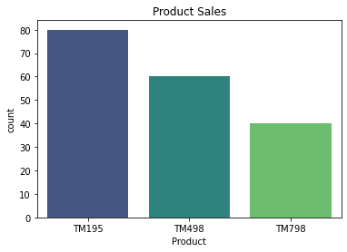

```python
# creating a countplot for categorical variable Products
plt.title('Product Sales')
sns.countplot(data=df, x='Product', palette ='viridis');
```

Observations:

- It is clear that TM195 is a popular product with 80 purchases, followed by TM498 with 60 purchases, and lastly TM798 with just 40 purchases.

#### Sales by gender

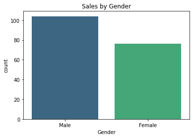

```python
# creating a countplot for categorical variable Gender
plt.title('Sales by Gender')
sns.countplot(data=df, x='Gender',palette ='viridis');
```

Observations:

- Men are more frequent customers than women, with the count being 104 men and 76 women.

#### Sales by marital status of customers

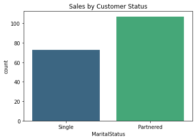

```python
# creating a countplot for categorical variable MaritalStatus
plt.title('Sales by Customer Status')
sns.countplot(data=df, x='MaritalStatus',palette ='viridis');
```

#### Influence of Education, Usage and Fitness on Purchase

Even though Education, Usage and Fitness are numerical variables, we will treat them as categorical variables because these variables can be divided into groups for meaningful representation. For example, 16 years of Education indicates a college graduate profile, while a Fitness score of 5 indicates a highly fit customer. We can plot countplots and boxplots in a side-by-side view to see the relationships.

##### Education

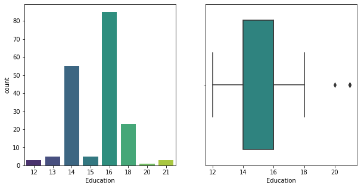

```python
# Plotting countplot and boxplots for the variable 'Education' in the same row, as two columns.

fig, ax =plt.subplots(1,2,figsize=(10,5))              # returns tuple containing figure and axes
plt.subplot(1,2,1,)                                    # the figure has 1 row, 2 columns and is the first plot
sns.countplot(x='Education',data=df,palette='viridis') #command to plot countplot
plt.subplot(1,2,2)                                     # the figure has 1 row, 2 columns and is the second plot
sns.boxplot(x='Education', data=df,palette='viridis')  #command to plot boxplot
plt.show()                                             #displays the plot
```

Observations:

- 50% of the dataset have 14-16 years of education, with the mode being 16 years -which means most customers are college educated.
- As indicated by the outliers, a very small subset(less than 10) have greater than 18 years of education, indicating a masters / post-graduation.

##### Fitness

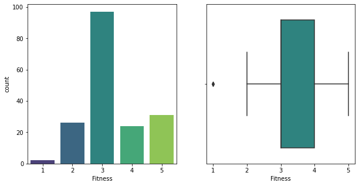

```python
# Plotting countplot and boxplots for the variable 'Fitness' in the same row, as two columns.

fig, ax =plt.subplots(1,2,figsize=(10,5))              # returns tuple containing figure and axes
plt.subplot(1,2,1,)                                    # the figure has 1 row, 2 columns and is the first plot
sns.countplot(x='Fitness',data=df,palette='viridis')   #command to plot countplot
plt.subplot(1,2,2)                                     # the figure has 1 row, 2 columns and is the second plot
sns.boxplot(x='Fitness', data=df, palette='viridis')   #command to plot boxplot
plt.show()                                             #displays the plot
```

##### Usage

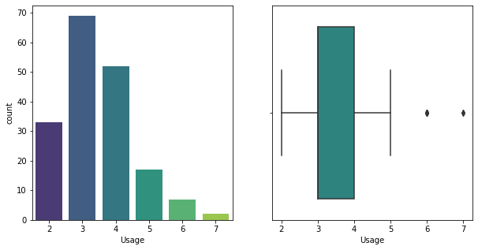

```python
# Plotting countplot and boxplots for the variable 'Usage' in the same row, as two columns.

fig, ax =plt.subplots(1,2,figsize=(10,5))                  # returns tuple containing figure and axes
plt.subplot(1,2,1,)                                        # the figure has 1 row, 2 columns and is the first plot
sns.countplot(x='Usage',data=df,palette='viridis')         #command to plot countplot
plt.subplot(1,2,2)                                         # the figure has 1 row, 2 columns and is the second plot
sns.boxplot(x='Usage', data=df,palette='viridis')          #command to plot boxplot
plt.show()                                                 #displays the plot
```

Observations:

- 50% of the users indicate they will use treadmills between 3&4 times a week.
- 69 customers recorded usage of 3 times a week, which is the most recorded usage number.
- Very few customers (less than 10) have recorded very high usage (usage score = 6&7)

#### Analysis of numerical variables.

In order to understand the distribution of numerical variables, we can plot histograms and boxplots in a side-by-side view.

#### Observations on Miles

We can plot histograms and boxplots of the Miles variable to see what customer preferences are.

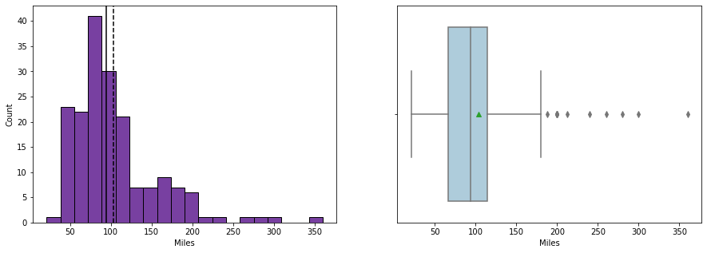

```python
# plotting combined histogram and boxplot for the variable 'Miles'
fig, ax =plt.subplots(1,2,figsize=(15,5))                         # returns tuple containing figure and axes
plt.subplot(1,2,1)                                                # the figure has 1 row, 2 columns and is the first plot
sns.histplot(data=df, x = 'Miles', color ='indigo');              #command to plot histplot
plt.axvline(df['Miles'].mean(), color="black", linestyle="--")    # Add mean to the histogram
plt.axvline(df['Miles'].median(), color="black", linestyle="-")   # Add median to the histogram
plt.subplot(1,2,2)                                                # the figure has 1 row, 2 columns and is the second plot
sns.boxplot(data=df, x = 'Miles',  palette ='Paired', showmeans = True);   #command to plot boxplot
```

Observations:

- The Miles histogram is right skewed, with the boxplot indicating outliers to the right, meaning there are customers who plan to run more Miles than the average customer.
- The average Miles that a customer plans to run is between 103 &104.
- 50% of the customers intend to run upto 94 miles on their product.

#### Understanding the influence of income on treadmill purchase

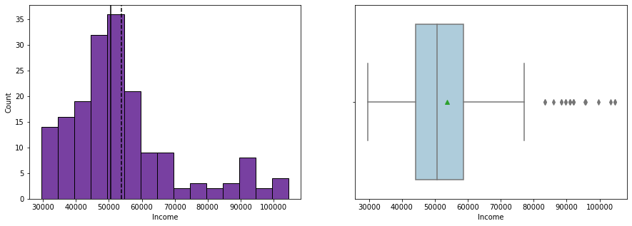

```python
# plotting combined histogram and boxplot for the variable 'Income'
fig, ax =plt.subplots(1,2,figsize=(15,5))                           # returns tuple containing figure and axes
plt.subplot(1,2,1)                                                  # the figure has 1 row, 2 columns and is the first plot
sns.histplot(data=df, x = 'Income', color ='indigo');               #command to plot histplot
plt.axvline(df['Income'].mean(), color="black", linestyle="--")     # Add mean to the histogram
plt.axvline(df['Income'].median(), color="black", linestyle="-")    # Add median to the histogram
plt.subplot(1,2,2)                                                  # the figure has 1 row, 2 columns and is the second plot
sns.boxplot(data=df, x = 'Income',  palette ='Paired', showmeans = True);          #command to plot boxplot
```

Observations:

- While customers have income ranging from (approx)29,500 to a max of (approx) 104,500, around 75% of customers have income around 58,000.
- The Income histogram is right skewed, and the boxplot indicates outliers, where customers have income greater than (approx) 78,000.

#### Understanding the influence of Age on purchase

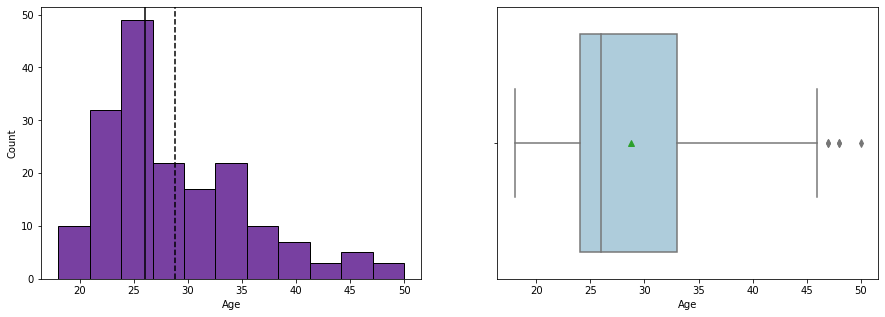

```python
# plotting combined histogram and boxplot for the variable  'Age'
ax =plt.subplots(1,2,figsize=(15,5))                                # returns tuple containing figure and axes
plt.subplot(1,2,1)                                                  # the figure has 1 row, 2 columns and is the first plot
sns.histplot(data=df, x = 'Age', color ='indigo');                  #command to plot histplot
plt.axvline(df['Age'].mean(), color="black", linestyle="--")        # Add mean to the histogram
plt.axvline(df['Age'].median(), color="black", linestyle="-")       # Add median to the histogram
plt.subplot(1,2,2)                                                  # the figure has 1 row, 2 columns and is the second plot
sns.boxplot(data=df, x = 'Age',  palette ='Paired',showmeans = True);     #command to plot boxplot
```

Observations:

- The Age boxplot indicates most customers can range from 18 years to 47 years, with some outliers greater than 47 years.
- 50% of the customers lie between 24 to 33 years.
- The age group 24 to 26 saw the highest number of customers, i.e, 48.

### Multivariate Analyses

We can conduct multivariate analyses on the Product to see how different parameters like Age, Gender, Income, etc influenced the purchase.

##### Gender and Product

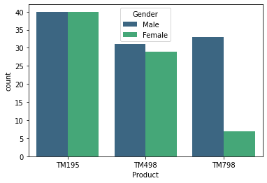

```python
# plot countplot on variable Product, with hue= Gender.
sns.countplot(data = df, x = 'Product', hue ='Gender', palette ='viridis');
```

Observations:

- Here we can see that, the most purchased treadmill is the TM195, with men and women equally preferring to purchase the treadmill.
- The TM798 treadmill is mostly preferred by men than women.
- The TM498 treadmill is slightly more preferred by men than women.

##### Product and Marital Status

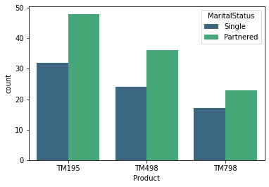

```python
# plot countplot on variable Product, with hue= MaritalStatus.
sns.countplot(data = df, x = 'Product', hue ='MaritalStatus', palette ='viridis');
```

Observations:

- Among the different products, the split between partnered/single is not significant enough to derive a relationship.
- However, the treadmill products are mostly purchased by partnered customers than single customers.

##### Gender and Marital Status

We can further plot the influence of Gender and Marital Status on the purchase of individual products to see if there is any valuable insight.

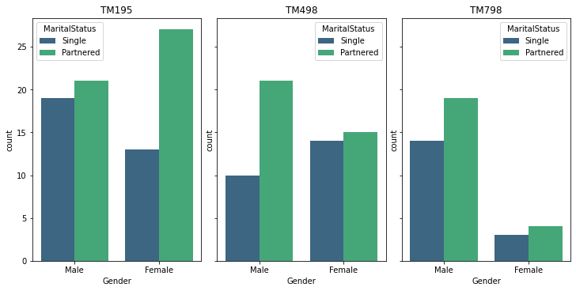

```python
# plotting the relationship between Gender and Marital Status for each product
# relationship is plotted in three subplots with a shared y-axis.

fig, ax =plt.subplots(1,3,figsize=(10,5),sharey=True, constrained_layout=True)
plt.subplot(1,3,1,)
plt.title('TM195')
sns.countplot(data = df.loc[df['Product'] == 'TM195'], x = 'Gender', hue ='MaritalStatus', palette ='viridis');
plt.subplot(1,3,2)
plt.title('TM498')
sns.countplot(data = df.loc[df['Product'] == 'TM498'], x = 'Gender', hue ='MaritalStatus', palette ='viridis');
plt.subplot(1,3,3)
plt.title('TM798')
sns.countplot(data = df.loc[df['Product'] == 'TM798'], x = 'Gender', hue ='MaritalStatus', palette ='viridis');
```

Observations:

- For all three products, partnered customers are the majority when compared to singles.
- Among the customers who purchased each product, TM195 was popular among partnered females, TM498 for partnered males. TM798 is generally popular among males than females, and even with the male customers, they are popular with partnered males.

##### Product and Fitness Scores

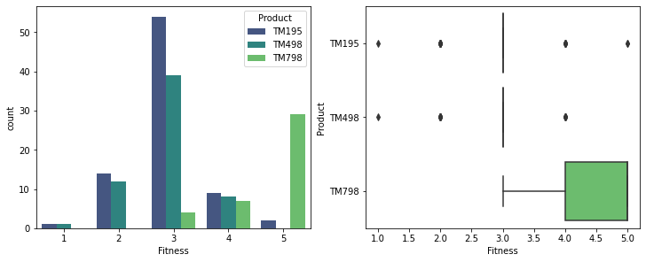

```python
# plot countplot and boxplot on variable Fitness.
fig, ax =plt.subplots(1,2,figsize=(10,4), constrained_layout=True)
plt.subplot(1,2,1,)
sns.countplot(data = df, x = 'Fitness', hue ='Product', palette ='viridis');
plt.subplot(1,2,2)
sns.boxplot(data = df, x = 'Fitness', y ='Product', palette ='viridis');
```

Observations:

- Customers with the highest fitness score prefer to purchase the TM798 model versus the people with the median score of 3 prefer to purchase the TM195 or TM498 model, with TM195 being more popular among the two.

##### Product and Usage

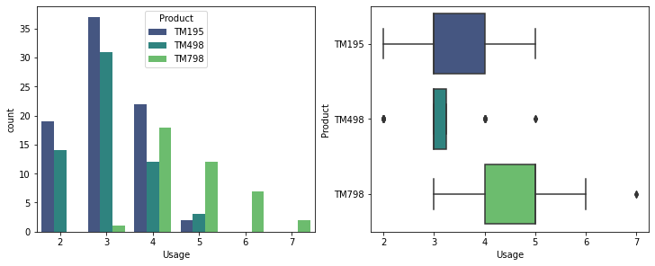

```python
# plot countplot and boxplot on variable Usage
fig, ax =plt.subplots(1,2,figsize=(10,4), constrained_layout=True)
plt.subplot(1,2,1,)
sns.countplot(data = df, x = 'Usage', hue='Product', palette ='viridis');
plt.subplot(1,2,2)
sns.boxplot(data = df, x = 'Usage', y ='Product', palette ='viridis');
```

Observations:

- Similar to the Fitness scores, it is clear that customers with higher usage (score 4 & above) prefer to use the TM798 model, whereas customers with the median usage score (3) prefer to use the TM195 model.
- TM195 users rate their usage between 2& 5, whereas TM798 users rate usage between 4 & 5. TM498 rates usage between 3 & 4.

##### Product and Age

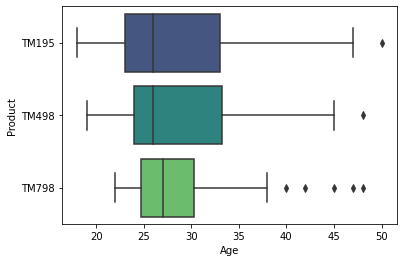

```python
# plot boxplot on variable Age and Product
sns.boxplot(data = df, y = 'Product', x='Age', palette ='viridis');
```

Observations:

- The median age of customers remain almost similar throughout the different products, approx 26-27.
- The TM195 & TM498 products are used by a wider range of age groups, from 18 to 47, whereas TM798 is used by a smaller range, from 23 to 37.

##### Product and Income

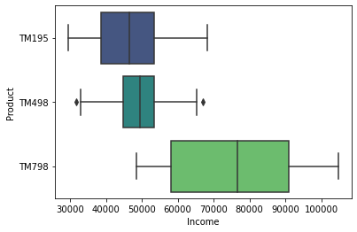

```python
# plot boxplot on variables Income and Product
sns.boxplot(data = df, x = 'Income', y='Product', palette ='viridis');
```

Observations:

- The TM195 and TM498 products are preferred by customers with income from 29,000 to 68,000 and 33,000 to 65,000.
- The TM798 product is preferred by customers with a higher income from 48,000 to 105,000.

##### Product and Education

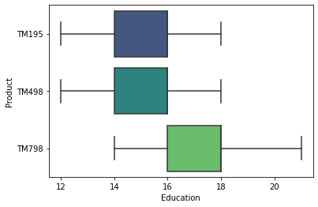

```python
# plot boxplot on variables Education and Product
sns.boxplot(data = df, x = 'Education', y='Product', palette ='viridis');
```

Observations:

- Customers of TM195 and TM498 have received between 12 and 18 years of education, whereas customers of the TM798 have higher education.

#### Exploring Correlations

This section will try to explore the correlations between the different variables, and see what relationships we can infer.

```python
# checking the correlation scores for all the variables in the dataset
df.corr()
```

|  | Age | Education | Usage | Fitness | Income | Miles |
| --- | --- | --- | --- | --- | --- | --- |
| Age | 1.000 | 0.280 | 0.015 | 0.061 | 0.513 | 0.037 |
| Education | 0.280 | 1.000 | 0.395 | 0.411 | 0.626 | 0.307 |
| Usage | 0.015 | 0.395 | 1.000 | 0.669 | 0.520 | 0.759 |
| Fitness | 0.061 | 0.411 | 0.669 | 1.000 | 0.535 | 0.786 |
| Income | 0.513 | 0.626 | 0.520 | 0.535 | 1.000 | 0.543 |
| Miles | 0.037 | 0.307 | 0.759 | 0.786 | 0.543 | 1.000 |

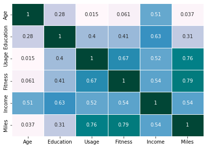

```python
# plotting the heatmap to view the correlation scores
plt. figure(figsize=(7,5))
sns.heatmap(df.corr(), annot=True, cbar = False, cmap ='PuBuGn',linewidth=1);
```

Observations:

- There are no negative correlations in the heatmap, and some of the positive correlations are very strong, with a score above 0.5.
- There are very strong correlations between the Income and Education variables. Of course, this would mean, that a higher educated customer would likely have a higher income. Income and Age also have a positive correlation but is not as strong as Income and Education.
- The fitness parameters have very strong correlations with each other. For example: Fitness and Miles have the highest correlation (0.79) indicating that the more fit a customer is, the more Miles he expects to complete on the product. Similarly, customers with higher Fitness scores are likely to use the products more (correlation = 0.67). Usage & Miles are also strongly correlated (0.76) indicating that the more you use the products, the more miles you are expecting to complete. We can validate if this correlation is positive for all products in the next graph.

#### Verifying positive correlations across products

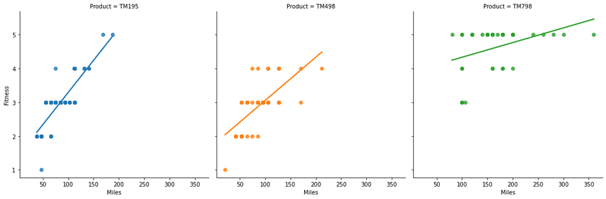

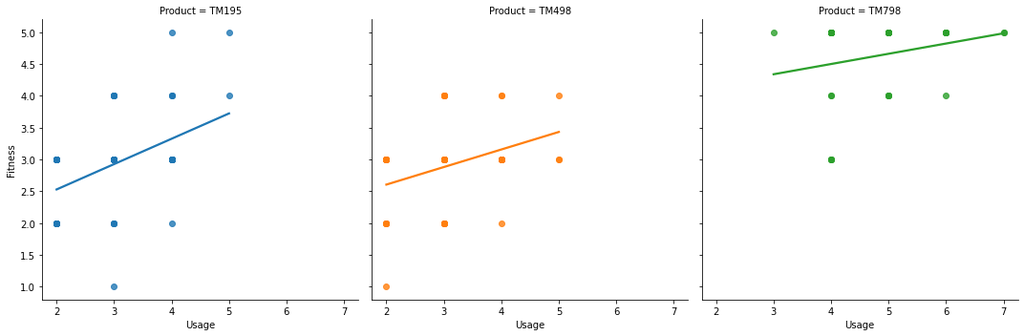

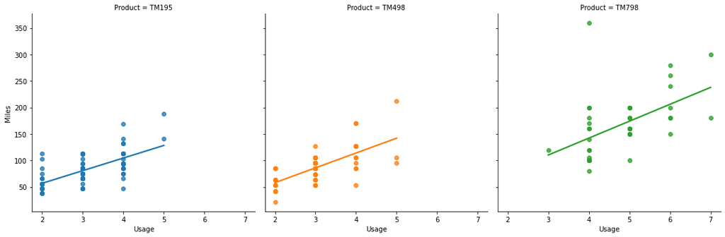

```python
#plotting linear model plot with best fit line for each product.
sns.lmplot(data=df, x = 'Miles', y='Fitness', col='Product' ,hue = 'Product', ci=False);
sns.lmplot(data=df, x = 'Usage', y='Fitness', col='Product' ,hue = 'Product', ci=False);
sns.lmplot(data=df, x = 'Usage', y='Miles', col='Product' ,hue = 'Product', ci=False);
```

Observations:

- We can notice that positive correlations exist between the different fitness-related parameters for each of the product.

### Key Insights

- TM195 is a popular product with 80 purchases, followed by TM498 with 60 purchases, and lastly TM798 with just 40 purchases.
- The average age of a customer is between 28 and 29, with 18 being the minimum and 50, being the maximum.
- Cardio Good Fitness products are more popular among men than among women. Also they are more popular with partnered people than with single customers.
- Among the customers who purchased each product, TM195 was popular among partnered females, TM498 for partnered males. TM798 is generally popular among males than females, and even with the male customers, they are popular with partnered males.
- Atleast 50% of the dataset are college-educated, with a few exceptional customers who have more years of education on them. Customers who have a higher education prefer to purchase the TM798 model.
- Customers with a higher fitness score prefer to purchase the TM798 model versus the people with the median score of 3 prefer to purchase the TM195 model.
- Similar to the Fitness scores, it is clear that customers with higher usage (score 4 & above) prefer to use the TM798 model, whereas customers with the median usage score (3) prefer to use the TM195 model.
- The TM195 & TM498 products are used by a wider range of age groups, from 18 to 47, whereas TM798 is used by a smaller range, from 23 to 37.
- TM195 and TM498 are preferred by customers with a lower income bracket (29,000 to 68,000), when compared to TM 798 which is purchased by customers with an income of 48,000 to 105,000.
- There are very strong correlations between the Income and Education variables, which would mean that a higher educated customer would likely have a higher income.
- The fitness parameters also have very strong correlations with each other. Fitness and Miles have the highest correlation (0.79) indicating that the more fit a customer is, the more Miles he expects to complete on the product. Similarly, customers with higher Fitness scores are likely to use the products more (correlation = 0.67). Usage & Miles are also strongly correlated (0.76) indicating that the more you use the products, the more miles you are expecting to complete.